# Practical_6_Correlation_analysis

```python
import numpy as np
import pandas as pd
import matplotlib.pyplot as plt
import seaborn as sns
```

```python
data=pd.read_csv("CarPrice_Assignment.csv")
data.head()
```

|  | car_ID | symboling | CarName | fueltype | aspiration | doornumber | carbody | drivewheel | enginelocation | wheelbase | ... | enginesize | fuelsystem | boreratio | stroke | compressionratio | horsepower | peakrpm | citympg | highwaympg | price |
| --- | --- | --- | --- | --- | --- | --- | --- | --- | --- | --- | --- | --- | --- | --- | --- | --- | --- | --- | --- | --- | --- |
| 0 | 1 | 3 | alfa-romero giulia | gas | std | two | convertible | rwd | front | 88.6 | ... | 130 | mpfi | 3.47 | 2.68 | 9.0 | 111 | 5000 | 21 | 27 | 13495.0 |
| 1 | 2 | 3 | alfa-romero stelvio | gas | std | two | convertible | rwd | front | 88.6 | ... | 130 | mpfi | 3.47 | 2.68 | 9.0 | 111 | 5000 | 21 | 27 | 16500.0 |
| 2 | 3 | 1 | alfa-romero Quadrifoglio | gas | std | two | hatchback | rwd | front | 94.5 | ... | 152 | mpfi | 2.68 | 3.47 | 9.0 | 154 | 5000 | 19 | 26 | 16500.0 |
| 3 | 4 | 2 | audi 100 ls | gas | std | four | sedan | fwd | front | 99.8 | ... | 109 | mpfi | 3.19 | 3.40 | 10.0 | 102 | 5500 | 24 | 30 | 13950.0 |
| 4 | 5 | 2 | audi 100ls | gas | std | four | sedan | 4wd | front | 99.4 | ... | 136 | mpfi | 3.19 | 3.40 | 8.0 | 115 | 5500 | 18 | 22 | 17450.0 |

5 rows × 26 columns

```python
data.pop("car_ID")
```

```
0        1
1        2
2        3
3        4
4        5
      ...
200    201
201    202
202    203
203    204
204    205
Name: car_ID, Length: 205, dtype: int64
```

```python
data=data.select_dtypes(include="number")
data
```

|  | symboling | wheelbase | carlength | carwidth | carheight | curbweight | enginesize | boreratio | stroke | compressionratio | horsepower | peakrpm | citympg | highwaympg | price |
| --- | --- | --- | --- | --- | --- | --- | --- | --- | --- | --- | --- | --- | --- | --- | --- |
| 0 | 3 | 88.6 | 168.8 | 64.1 | 48.8 | 2548 | 130 | 3.47 | 2.68 | 9.0 | 111 | 5000 | 21 | 27 | 13495.0 |
| 1 | 3 | 88.6 | 168.8 | 64.1 | 48.8 | 2548 | 130 | 3.47 | 2.68 | 9.0 | 111 | 5000 | 21 | 27 | 16500.0 |
| 2 | 1 | 94.5 | 171.2 | 65.5 | 52.4 | 2823 | 152 | 2.68 | 3.47 | 9.0 | 154 | 5000 | 19 | 26 | 16500.0 |
| 3 | 2 | 99.8 | 176.6 | 66.2 | 54.3 | 2337 | 109 | 3.19 | 3.40 | 10.0 | 102 | 5500 | 24 | 30 | 13950.0 |
| 4 | 2 | 99.4 | 176.6 | 66.4 | 54.3 | 2824 | 136 | 3.19 | 3.40 | 8.0 | 115 | 5500 | 18 | 22 | 17450.0 |
| ... | ... | ... | ... | ... | ... | ... | ... | ... | ... | ... | ... | ... | ... | ... | ... |
| 200 | -1 | 109.1 | 188.8 | 68.9 | 55.5 | 2952 | 141 | 3.78 | 3.15 | 9.5 | 114 | 5400 | 23 | 28 | 16845.0 |
| 201 | -1 | 109.1 | 188.8 | 68.8 | 55.5 | 3049 | 141 | 3.78 | 3.15 | 8.7 | 160 | 5300 | 19 | 25 | 19045.0 |
| 202 | -1 | 109.1 | 188.8 | 68.9 | 55.5 | 3012 | 173 | 3.58 | 2.87 | 8.8 | 134 | 5500 | 18 | 23 | 21485.0 |
| 203 | -1 | 109.1 | 188.8 | 68.9 | 55.5 | 3217 | 145 | 3.01 | 3.40 | 23.0 | 106 | 4800 | 26 | 27 | 22470.0 |
| 204 | -1 | 109.1 | 188.8 | 68.9 | 55.5 | 3062 | 141 | 3.78 | 3.15 | 9.5 | 114 | 5400 | 19 | 25 | 22625.0 |

205 rows × 15 columns

```python
corr= data.corr()
corr=corr[(corr>0.5)|(corr<-0.5)]
corr
```

|  | symboling | wheelbase | carlength | carwidth | carheight | curbweight | enginesize | boreratio | stroke | compressionratio | horsepower | peakrpm | citympg | highwaympg | price |
| --- | --- | --- | --- | --- | --- | --- | --- | --- | --- | --- | --- | --- | --- | --- | --- |
| symboling | 1.000000 | -0.531954 | NaN | NaN | -0.541038 | NaN | NaN | NaN | NaN | NaN | NaN | NaN | NaN | NaN | NaN |
| wheelbase | -0.531954 | 1.000000 | 0.874587 | 0.795144 | 0.589435 | 0.776386 | 0.569329 | NaN | NaN | NaN | NaN | NaN | NaN | -0.544082 | 0.577816 |
| carlength | NaN | 0.874587 | 1.000000 | 0.841118 | NaN | 0.877728 | 0.683360 | 0.606454 | NaN | NaN | 0.552623 | NaN | -0.670909 | -0.704662 | 0.682920 |
| carwidth | NaN | 0.795144 | 0.841118 | 1.000000 | NaN | 0.867032 | 0.735433 | 0.559150 | NaN | NaN | 0.640732 | NaN | -0.642704 | -0.677218 | 0.759325 |
| carheight | -0.541038 | 0.589435 | NaN | NaN | 1.000000 | NaN | NaN | NaN | NaN | NaN | NaN | NaN | NaN | NaN | NaN |
| curbweight | NaN | 0.776386 | 0.877728 | 0.867032 | NaN | 1.000000 | 0.850594 | 0.648480 | NaN | NaN | 0.750739 | NaN | -0.757414 | -0.797465 | 0.835305 |
| enginesize | NaN | 0.569329 | 0.683360 | 0.735433 | NaN | 0.850594 | 1.000000 | 0.583774 | NaN | NaN | 0.809769 | NaN | -0.653658 | -0.677470 | 0.874145 |
| boreratio | NaN | NaN | 0.606454 | 0.559150 | NaN | 0.648480 | 0.583774 | 1.000000 | NaN | NaN | 0.573677 | NaN | -0.584532 | -0.587012 | 0.553173 |
| stroke | NaN | NaN | NaN | NaN | NaN | NaN | NaN | NaN | 1.0 | NaN | NaN | NaN | NaN | NaN | NaN |
| compressionratio | NaN | NaN | NaN | NaN | NaN | NaN | NaN | NaN | NaN | 1.0 | NaN | NaN | NaN | NaN | NaN |
| horsepower | NaN | NaN | 0.552623 | 0.640732 | NaN | 0.750739 | 0.809769 | 0.573677 | NaN | NaN | 1.000000 | NaN | -0.801456 | -0.770544 | 0.808139 |
| peakrpm | NaN | NaN | NaN | NaN | NaN | NaN | NaN | NaN | NaN | NaN | NaN | 1.0 | NaN | NaN | NaN |
| citympg | NaN | NaN | -0.670909 | -0.642704 | NaN | -0.757414 | -0.653658 | -0.584532 | NaN | NaN | -0.801456 | NaN | 1.000000 | 0.971337 | -0.685751 |
| highwaympg | NaN | -0.544082 | -0.704662 | -0.677218 | NaN | -0.797465 | -0.677470 | -0.587012 | NaN | NaN | -0.770544 | NaN | 0.971337 | 1.000000 | -0.697599 |
| price | NaN | 0.577816 | 0.682920 | 0.759325 | NaN | 0.835305 | 0.874145 | 0.553173 | NaN | NaN | 0.808139 | NaN | -0.685751 | -0.697599 | 1.000000 |

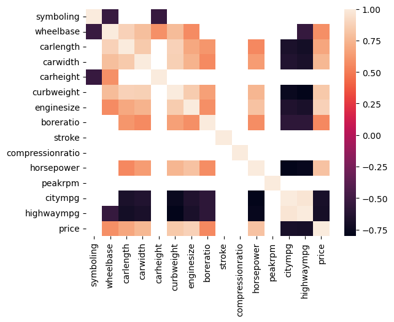

```python
sns.heatmap(corr)
```

# Inferences

## Positive correlation

### Strong

1. Car length and wheelbase, ie as the car length increases, the distance between the centers of the front and backwheel also increases.
2. Wheelbase and car width, as the distance between the front and back wheel increases, the width of the car also increases
3. Wheelbase and weight are also directly proportional
4. Car length and car width show strong correlation, ie as the length increases the width also increases
5. car width and curb weight, more width means more material and hence more weight.
6. Curb weight and engine size, more weight requires more power to pull the car forward
7. Curb weight and price, more weight means more material means more price, also means more power from the engine hence more costs for development of the engine again contributes to this strong correlation
8. Engine size and price,the bigger the engine the more power it generates and hence more development costs and material costs are associated with it. Also bigger engine size models are the higher variants hence the price goes as the engine size goes up.
9. Horsepower and price, the more power the engine generates the price goes up, this is true when we see sportscars.
10. highway mpg and city mpg, shows a very strong correlation meaning that either of as the city mileage increases or decreases, so does the other, which is very in the real world as well.

### Moderate correlation

1. wheelbase and car height, enginesize, price also also show a moderate correlation
2. car width and engine size, boreratio,horsepower,price all show moderate correlation, as the width increases, the weight increases and hence more power is required is pull the car forward. And all these measures are related to generating power, hence as they go up, the car width also goes up.
3. Curb weight and boreratio, horsepower. This can be explained using the same reason as the one above.
4. Car length and engine size, boreratio, horsepower. Same explaination as the car width.
5. engine size and bore ratio. The bore is the diameter of the cyclinder in the engine. As the engine size increases, the bore usually increases but this may not always be true. Hence they show a moderate correlation and not a very strong one.

## Negative Correlation

### Strong

1. Horsepower and mileage(city mpg and highway mpg). As the horsepower increases,it burns more fuel in less time and hence the mileage goes down.